# Euronet - rekrutacja

Adrian Dybowski

13-02-2023

##### Potrzebne biblioteki:

```r
library(data.table)
library(dplyr)
library(lubridate)
library(ggplot2)
library(graphics)
library(scales)
library(stats)
library(glue)
library(forecast)
library(knitr)
library(kableExtra)
```

### Punkt 1.

##### Wczytanie i scalenie plików z danymi:

```r
data_atm_1 <- data.table::fread('Dane/data_ATM1.csv')
data_atm_2 <- data.table::fread('Dane/data_ATM2.csv')
data_atm_3 <- data.table::fread('Dane/data_ATM3.csv')
data_atm_4 <- data.table::fread('Dane/data_ATM4.csv')
data_atm_5 <- data.table::fread('Dane/data_ATM5.csv')
data_atm_6 <- data.table::fread('Dane/data_ATM6.csv')
data_atm_7 <- data.table::fread('Dane/data_ATM7.csv')
data_atm_8 <- data.table::fread('Dane/data_ATM8.csv')
data_atm_9 <- data.table::fread('Dane/data_ATM9.csv')

data <- data.table::rbindlist(list(data_atm_1, data_atm_2, data_atm_3,
                                   data_atm_4, data_atm_5, data_atm_6,
                                   data_atm_7, data_atm_8, data_atm_9))
```

### Punkt 2.

##### Przygotowanie odpwiednich kolumn, które będą służyć do grupowania:

```r
data[, Month := lubridate::month(ProcessDate, label = TRUE)]
data[, MonthDay := lubridate::mday(ProcessDate)]
data[, WeekDay := lubridate::wday(ProcessDate, label = TRUE)]
data[, WeekDay := gsub("\\\\.", "", WeekDay)]
```

##### Analiza na podstawie metryk okresu czasu:

```r
monthly_analysis <- data[, .(Withdrawal_sum = sum(Withdrawal)), .(Month)]
month_day_analysis <- data[, .(Withdrawal_sum = sum(Withdrawal)), .(MonthDay)]
week_day_analysis <- data[, .(Withdrawal_sum = sum(Withdrawal)), .(WeekDay)]
week_day_analysis <- week_day_analysis[, WeekDay := factor(WeekDay, levels = c(
  'pt', 'czw', 'sob', 'pon', 'śr', 'wt', 'niedz'
))]
```

##### Kody wykresów:

```r
monthly_analysis_plot <- ggplot2::ggplot(data = monthly_analysis) +
  ggplot2::geom_line(aes(x = Month, y = Withdrawal_sum, group = 1), color = 'red') +
  ggplot2::labs(x = 'Miesiąc', y = 'Suma wypłat',
                title = 'Suma wypłat w bankomatach z podziałem na miesiące') +
  ggplot2::scale_y_continuous(labels = scales::comma)

month_day_analysis_plot <- ggplot2::ggplot(data = month_day_analysis) +
  ggplot2::geom_line(aes(x = MonthDay, y = Withdrawal_sum, group = 1), color = 'blue') +
  ggplot2::labs(x = 'Dzień miesiąca', y = 'Suma wypłat',
                title = 'Suma wypłat w bankomatach z podziałem na dni miesiąca') +
  ggplot2::scale_y_continuous(labels = scales::comma)

week_day_analysis_plot <- ggplot2::ggplot(data = week_day_analysis) +
  ggplot2::geom_col(aes(x = WeekDay, y = Withdrawal_sum, group = 1),
                    fill = 'green') +
  ggplot2::labs(x = 'Dzień tygodnia', y = 'Suma wypłat',
                title = 'Suma wypłat w bankomatach z podziałem na dni tygodnia') +
  ggplot2::scale_y_continuous(labels = scales::comma)
```

##### Wizualizacja:

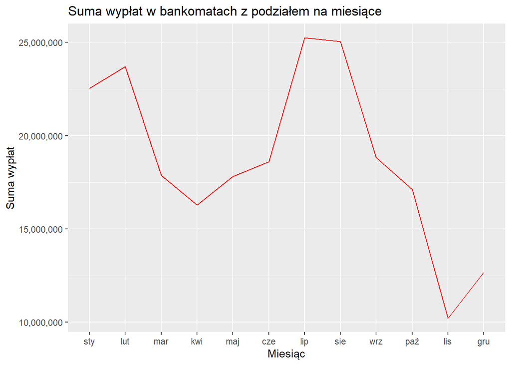

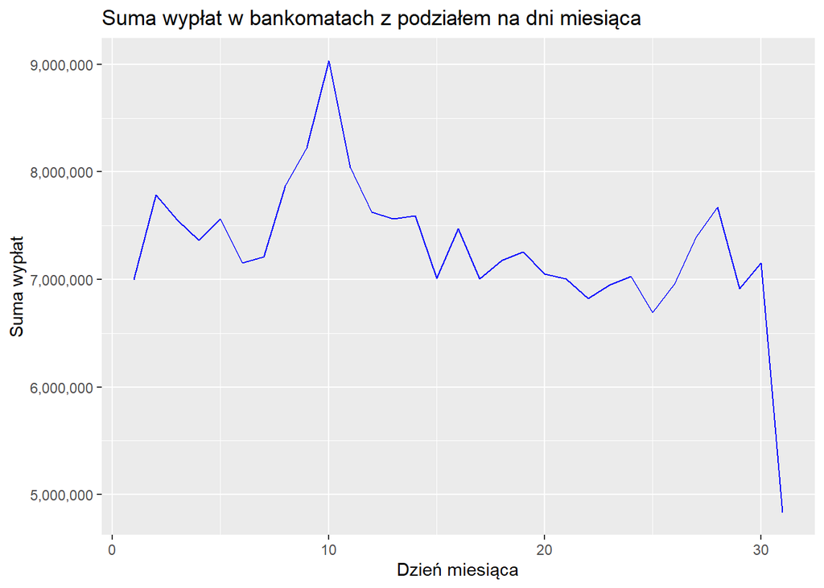

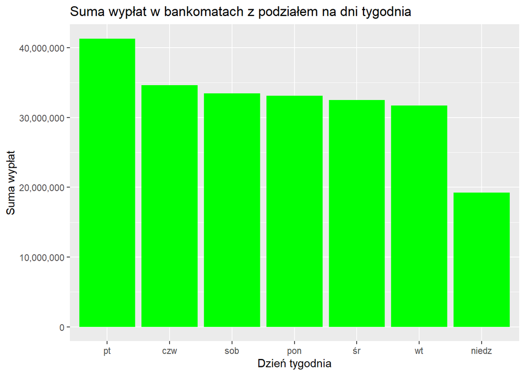

##### Opis wykresów:

Patrząc na wykres miesięczny możemy zaobserować, że najwyższe wypłaty z bankomatów przypadają na miesiące styczeń i luty oraz lipiec i sierpień. Pierwsza myśl jaka przychodzi tutaj, to że może mieć to związek z feriami i wakacjami. Ludzie częściej korzystają z urlopów w tych okresach, więc częściej może być im potrzebna na przykład gotówka z bankomatu. Najmniej wypłat przypada na koniec roku - listopad i grudzień. Przede wszystkim ma to związek z tym, że badany okres jest niepełny - brakuje listopada i grudnia 2019 roku do pełnego trzyletniego okresu, więc dla tych miesięcy brakuje 33,3 % danych. Natomiast i tak zastanawiający jest grudzień, gdyż mamy wtedy święta Bożego Narodzenia, ludzie wydają wtedy sporo pieniędzy na prezenty i zakupy świąteczne a nawet jakbyśmy w najprostszym rozumowaniu dodali do grudnia średnią ilość wypłat z poprzednich grudni to byłby on gdzieś w środku stawki.

Wykres z podziałem na dni miesiąca pokazuje, że zdecydowanie najwięcej wypłat występuje 10. dnia miesiąca, a najmniej ostatniego dnia miesiąca. Tutaj można się pokusić o stwierdzenie, że wpływ na to może mieć otrzymywanie wynagrodzeń z pracy. Większość firm stosuje zasadę wypłacania pienięniędzy za pracę do 10. dnia miesiąca, a zazwyczaj przypada to na 8., 9. lub 10. dzień miesiąca. Znaczący przypływ ieniędzy na konto działa zachęcająco do wydania części tej sumy, zrobienia wszelkich opłat miesięcznych, itd.

Wykres z odziałem na dni tygodnia pokazuje, że najwięcej wypłacanej gotówki jest w piątek, czyli na początek weekendu, kiedy to spora liczba osób wybiera się na zakupy, rozrywkę, imprezy. Najmniejszy wynik w przypadku niedzieli może mieć związek z ograniczeniami w handlu wprowadzonymi kilka lat temu przez rząd polski (zamknięcie sklepów i galerii handlowych).

### Punkt 3.

##### Wybrany model wraz z krótkim opisem oraz opis błędów:

ARIMA (AutoRegressive Integrated Moving Average) jest popularnym modelem statystycznym, który jest używany do prognozowania szeregów czasowych. Model opiera się na analizie trendów i sezonowości w danych historycznych, a także na wprowadzeniu korekty dla tendencji i sezonowości, aby lepiej przewidzieć przyszłe wartości. W procesie tworzenia modelu ARIMA, wyznaczane są różne parametry, takie jak autoregresja (AR), integracja (I) i średnia ruchoma (MA), które są następnie używane do prognozowania wartości w przyszłości. Model ten jest uważany za jednego z najbardziej elastycznych i uniwersalnych modeli prognozowania, ponieważ może być dostosowany do różnych typów danych i sytuacji biznesowych.

Błąd prognozy modelu ARIMA będzie mierzony jako różnica między wartościami prognozowanymi przez model a wartościami rzeczywistymi dla danych prognozowanych. Na przykład, jeśli nasz model prognozuje sprzedaż na poziomie 100 produktów na kolejny dzień, a rzeczywista sprzedaż wynosi 120 produktów, to nasz błąd prognozy wynosi 20 produktów.

Błąd dopasowania modelu ARIMA będzie mierzony jako różnica między wartościami prognozowanymi przez model a wartościami rzeczywistymi dla danych historycznych. Na przykład, jeśli nasz model prognozuje sprzedaż na poziomie 90 produktów w dniu 10, a rzeczywista sprzedaż wynosi 100 produktów, to nasz błąd dopasowania wynosi 10 produktów.

##### Kod

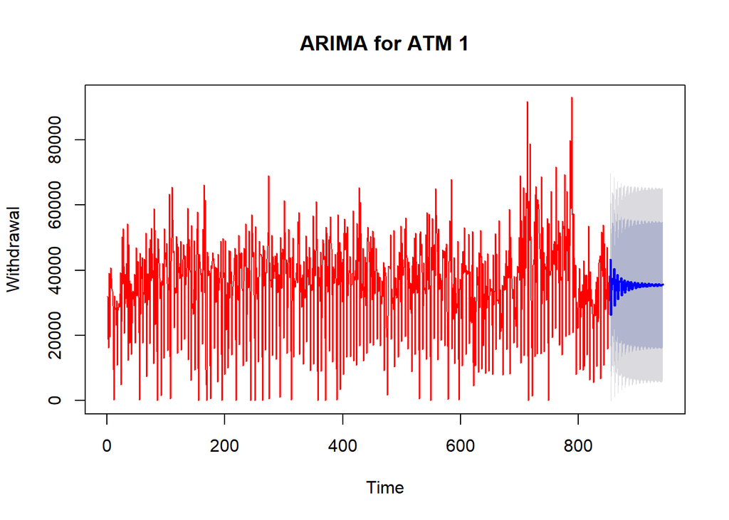

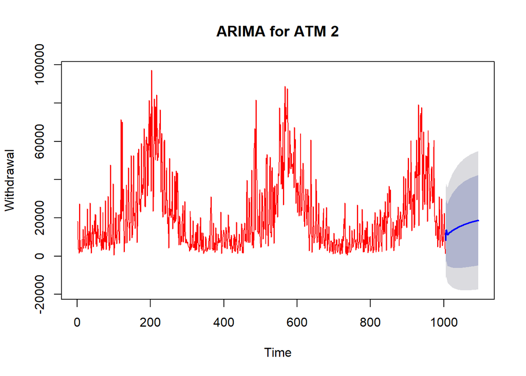

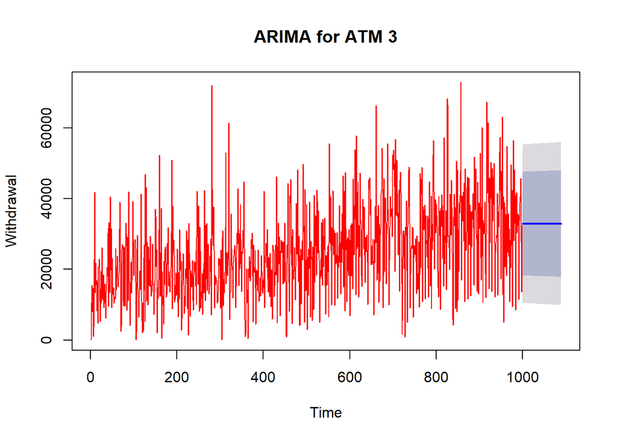

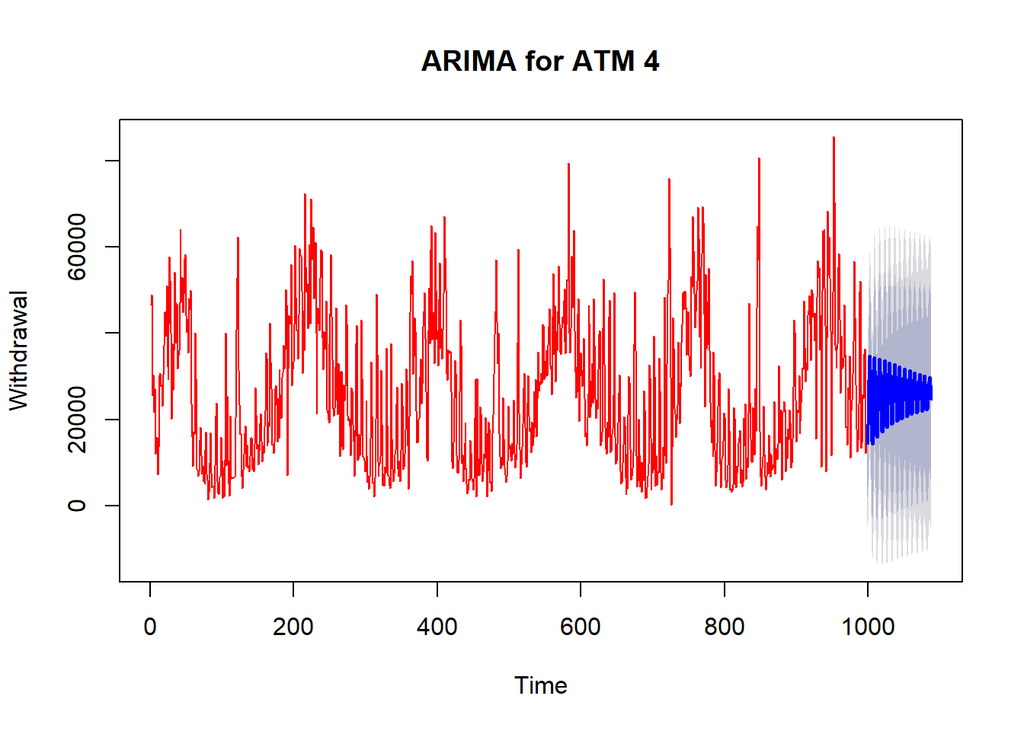

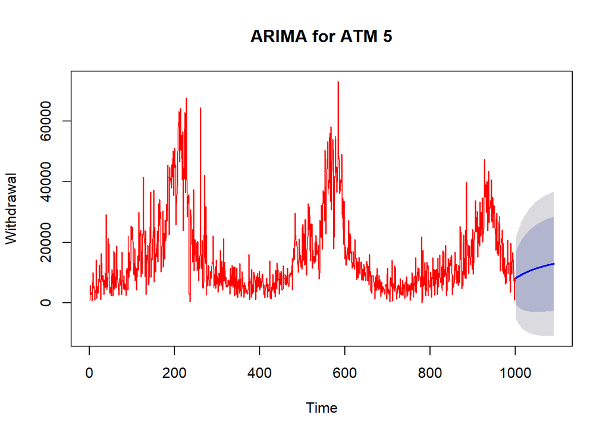

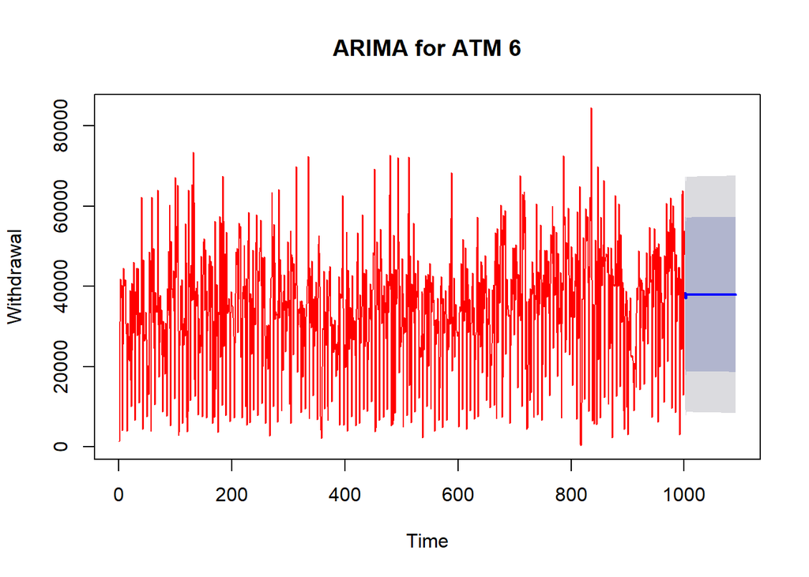

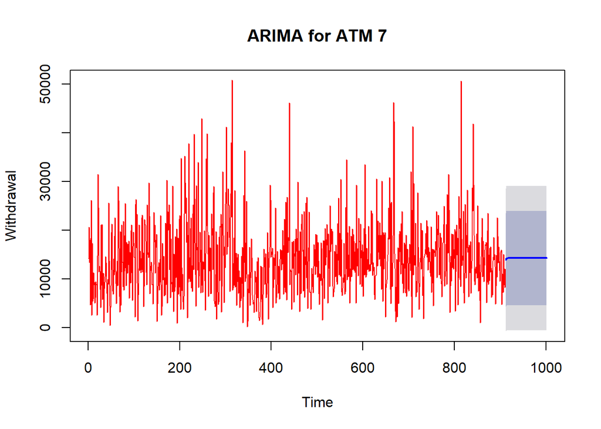

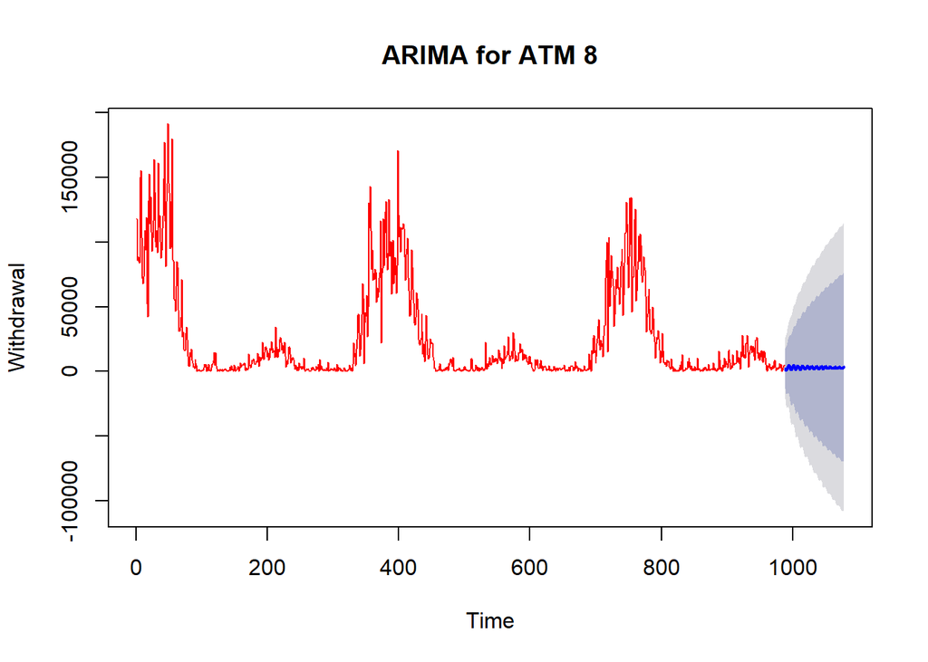

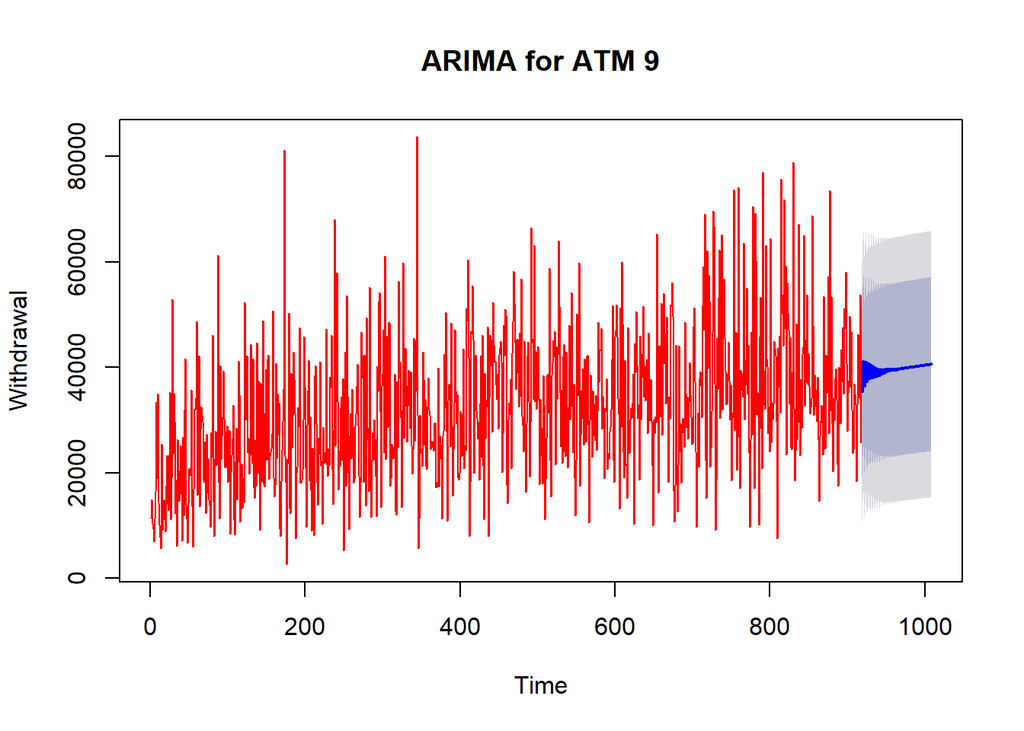

```r
errors_table <- data.table::data.table()

for (i in 1:9) {

  data_temp <- data[Atm == glue::glue("ATM{i}")]

  # Podział na zbiór testowy i treningowy
  ts_data <- stats::ts(data_temp$Withdrawal, frequency = 365)
  train <- ts_data[1:(length(ts_data) - 30)]
  test <- ts_data[(length(ts_data) - 29):length(ts_data)]

  # Model ARIMA
  model <- forecast::auto.arima(train)

  # Prognoza na części testowej
  forecast <- forecast::forecast(model, h = 30)

  # Obliczenie błędu prognozy
  forecast_diff <- forecast$mean - test
  error_forecast <- mean(forecast_diff)

  # Policzenie błędu dopasowania
  fit_diff <- train - stats::fitted(model)
  error_fit <- mean(fit_diff)

  # Połączenie błędów w tabelę
  errors_table_temp <- data.table::data.table(Atm = glue::glue('ATM_{i}'),
                                              ForecastError = round(error_forecast, 3),
                                              FitError = round(error_fit, 3))
  errors_table <- data.table::rbindlist(list(errors_table, errors_table_temp))

  # Prognoza na 60 dni
  forecast_60_days <- forecast::forecast(model, h = 90)
  plot_temp <- graphics::plot(forecast_60_days,
                              col = "red", xlab = "Time", ylab = "Withdrawal",
                              main = glue::glue("ARIMA for ATM {i}"), type = 'l')
  assign(paste("plot_atm_", i), plot_temp)

  # Usunięcie zmiennych, aby były gotoe do następnej pętli
  rm(ts_data, train, test, model, forecast, forecast_diff, error_forecast,
     error_fit, fit_diff, forecast_60_days, plot_temp)
}
```

##### Tabela z błędami dla wszystkich szeregów:

| Atm | ForecastError | FitError |
| --- | --- | --- |
| ATM_1 | 322.564 | 0.622 |
| ATM_2 | 5478.622 | -1.420 |
| ATM_3 | -836.168 | 784.614 |
| ATM_4 | 3742.706 | -14.788 |
| ATM_5 | 13.661 | 19.279 |
| ATM_6 | -52.446 | 622.486 |
| ATM_7 | -104.725 | -0.318 |
| ATM_8 | -4026.287 | -223.748 |
| ATM_9 | 2889.411 | 182.674 |

### Punkt 4.

##### Zapytanie SQL:

```r
"SELECT *
FROM (SELECT Atm, ProcessDate, Currency, Withdrawal, Deposit,
      row_number() OVER (PARTITION BY Atm ORDER BY ProcessDate DESC) AS ProcessDateOrder
      FROM Atm_History) Atm_History_Temp
WHERE Atm_History_Temp.ProcessDateOrder = 1;"
```

```
## [1] "SELECT *\nFROM (SELECT Atm, ProcessDate, Currency, Withdrawal, Deposit,\n      row_number() OVER (PARTITION BY Atm ORDER BY ProcessDate DESC) AS ProcessDateOrder\n      FROM Atm_History) Atm_History_Temp\nWHERE Atm_History_Temp.ProcessDateOrder = 1;"
```